# Camila Rodriguez Lab9, ENVIRON 710

## Setup

```r
#install.packages("DHARMa")
#install.packages("gtsummary")
library(gtsummary)

library(DHARMa)
library(here)
library(tidyverse)

lizards<- read.csv('jrn_lizard.csv')

lizards<- lizards %>% filter(spp== "UTST")

#unique(lizards$zone)
```

### Research Question: Do snout to vent length, sex, and vegetation zone at time of capture significantly predict if a lizard tail is recorded as whole?

## Data Visualization

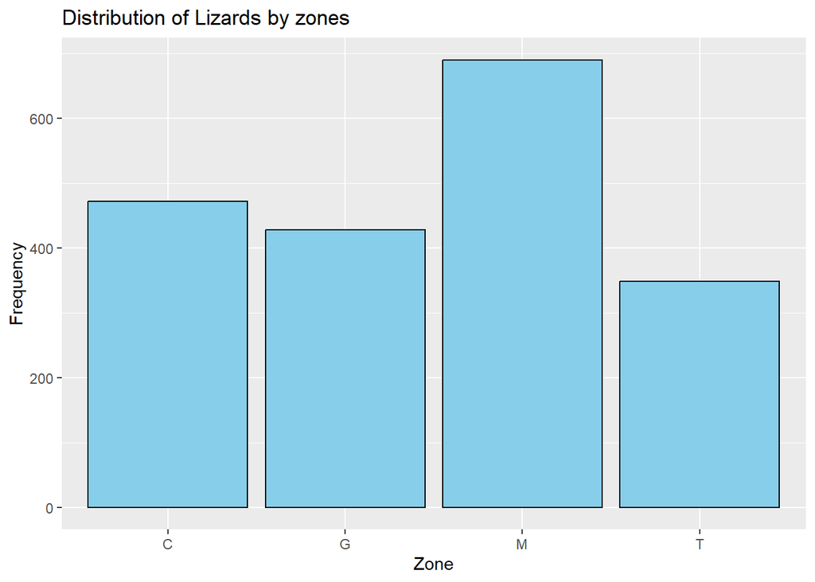

```r
# Plot 1: Bar Plot of Lizards by Zone
p1 <- ggplot(lizards, aes(x = zone)) +
  geom_bar(fill = "skyblue", color = "black") +
  labs(title = "Distribution of Lizards by zones", x = "Zone", y = "Frequency")

# Plot 2: Sex Distribution
#filter out N/A sexes

lizards <- lizards %>%
  filter(sex %in% c("F", "M", "J") & !is.na(sex))


p2 <- ggplot(lizards, aes(x = sex)) +
  geom_bar(binwidth = 1, fill = "lightgreen", color = "black") +
  labs(title = "Distribution of Lizards by Sex ", x = "Sex", y = "Frequency")
# Plot 3: Snout to vent length
p3 <- ggplot(lizards, aes(x = SV_length)) +
  geom_histogram(fill = "coral", color = "black") +
  labs(title = "Lizard distribution of snout to vent lengths", x = "Snout to Vent Length ", y = "Number of Observations")
#left skewed

p4<- ggplot(lizards, aes(x=zone, y=SV_length))+ geom_boxplot()

p5<- ggplot(lizards, aes(x=sex, y=SV_length))+ geom_boxplot()



# View plots and analyze possible correlations
p1
```

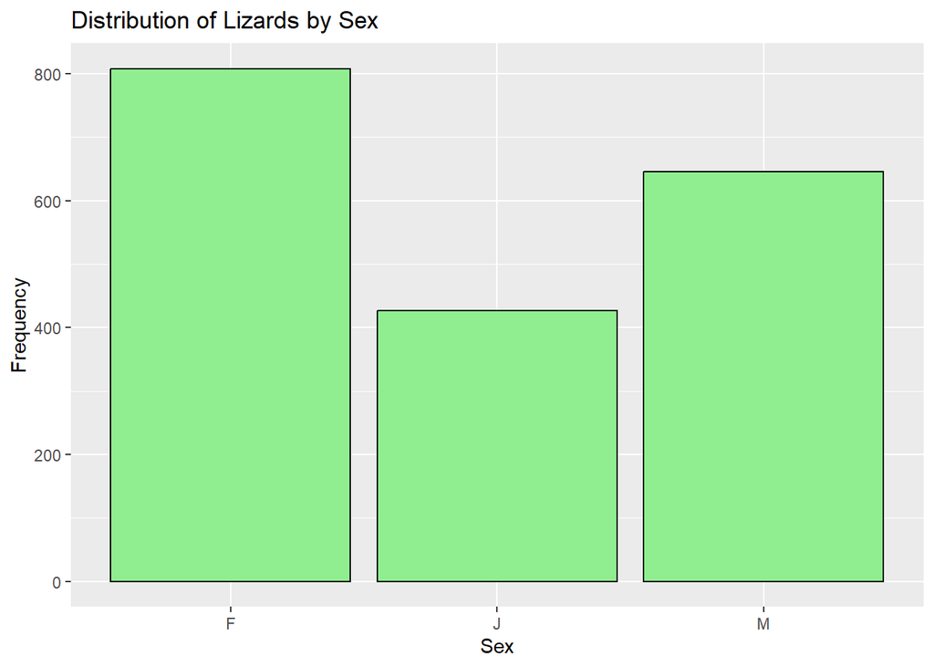

```r
p2
```

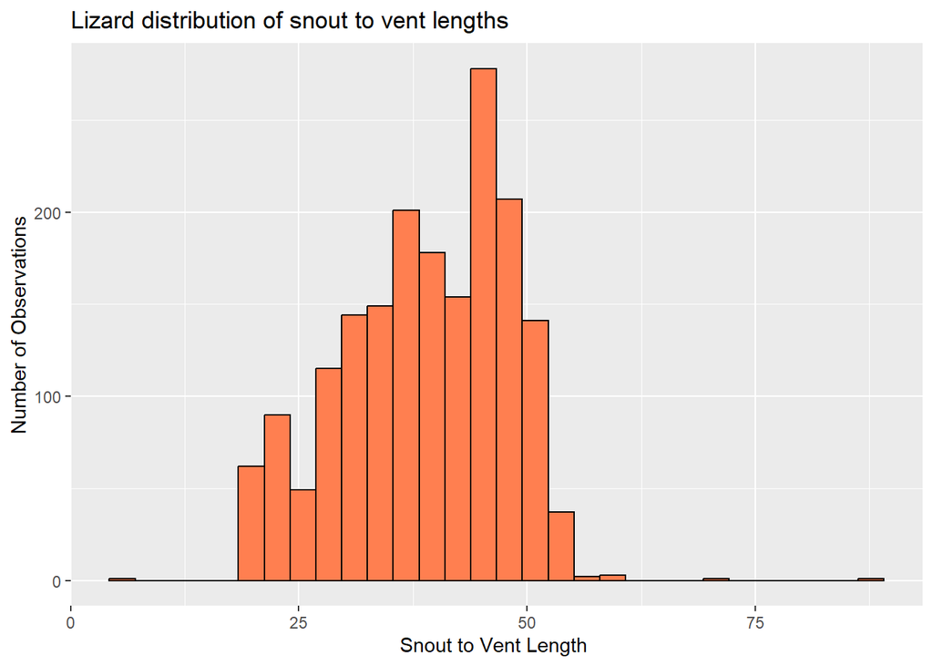

```r
p3
```

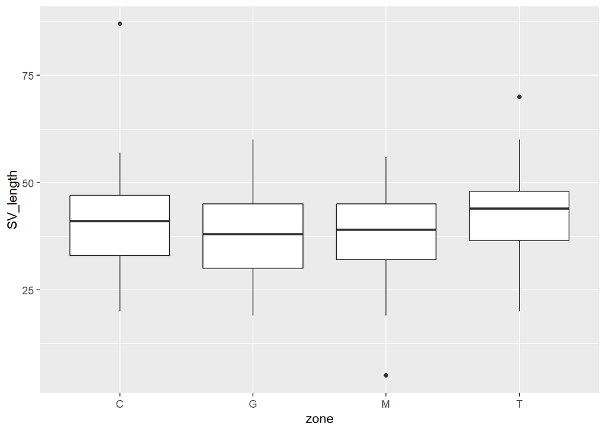

```r
p4
```

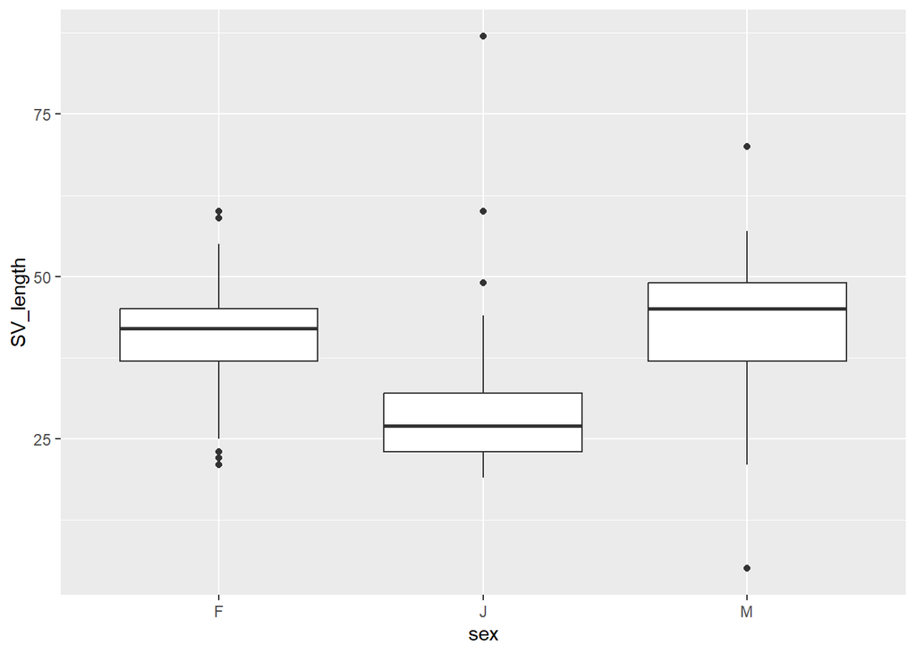

```r
p5
```

## Fit Regresison

```r
#convert necessary data into factors for GLM

lizards$sex <- factor(lizards$sex, levels= c("J", "F", "M"))
#unique(lizards$sex)

lizards$zone <- factor(lizards$zone, levels= c("C", "G", "M", "T"))
#unique(lizards$zone)

#filter out NAs from tails, make into factor
lizards <- lizards %>%
  filter(tail %in% c("B", "W")) %>%
  mutate(tail = factor(tail, levels = c("B", "W")))

tail_model<- glm(tail~ sex + zone+ SV_length, data= lizards, family= "binomial")
```

## Evaluate Model Diagnostics

The results of a logistic regression suggest that the log-odds of having a tail are significantly lower in zone G (β = -0.57, p = 0.001) and zone T (β = -0.40, p = 0.025) relative to the reference zone (C). There was also a significant negative relationship between SV length and the log-odds of having a tail (β = -0.045, p < 0.001). Although zone M had a negative coefficient (β = -0.30), this effect was marginally non-significant (p = 0.063). Neither sex (female: β = -0.20, p = 0.32; male: β = -0.14, p = 0.53) was significantly associated with the log-odds of having a tail.

```r
summary(tail_model)
```

```
##
## Call:
## glm(formula = tail ~ sex + zone + SV_length, family = "binomial",
##     data = lizards)
##
## Coefficients:
##              Estimate Std. Error z value Pr(>|z|)
## (Intercept)  3.493940   0.332420  10.511  < 2e-16 ***
## sexF        -0.203871   0.206033  -0.990  0.32241
## sexM        -0.138956   0.223664  -0.621  0.53442
## zoneG       -0.565369   0.173745  -3.254  0.00114 **
## zoneM       -0.301313   0.162032  -1.860  0.06294 .
## zoneT       -0.404349   0.179938  -2.247  0.02463 *
## SV_length   -0.045230   0.008877  -5.095 3.49e-07 ***
## ---
## Signif. codes:  0 '***' 0.001 '**' 0.01 '*' 0.05 '.' 0.1 ' ' 1
##
## (Dispersion parameter for binomial family taken to be 1)
##
##     Null deviance: 1931.7  on 1799  degrees of freedom
## Residual deviance: 1867.3  on 1793  degrees of freedom
##   (27 observations deleted due to missingness)
## AIC: 1881.3
##
## Number of Fisher Scoring iterations: 4
```

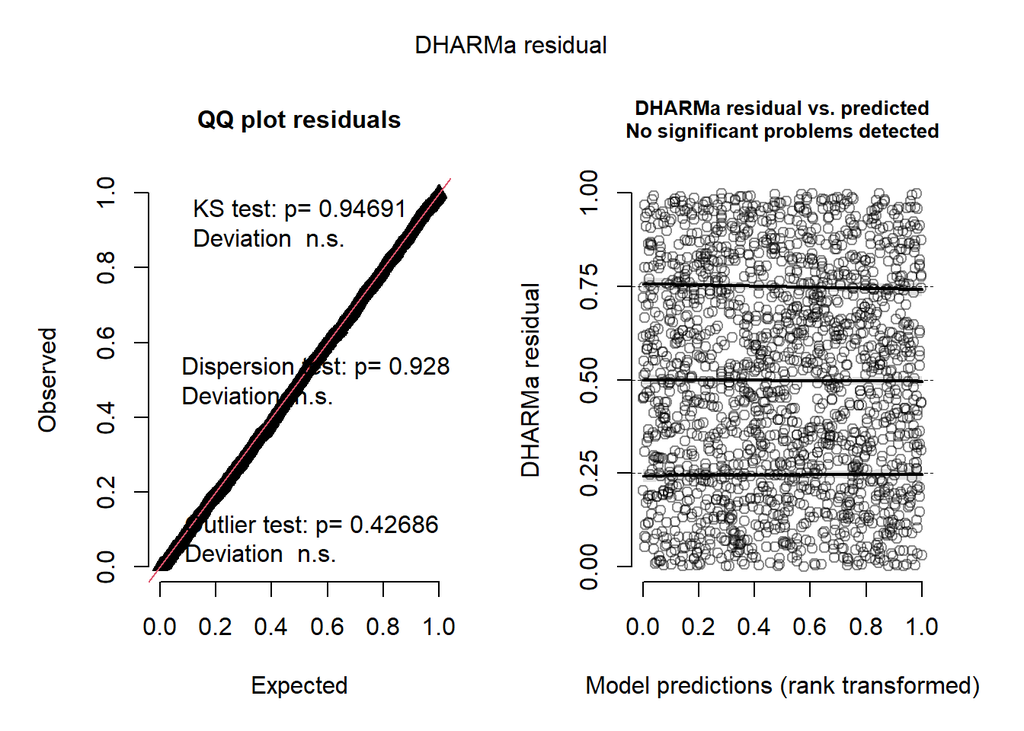

```r
simulateResiduals(tail_model) %>% plot()
```

##Probability Graphs for Zones and Sexes, Snout to Vent Length

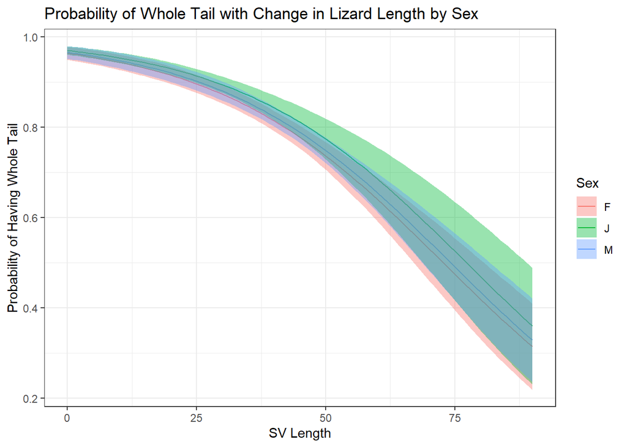

```r
#graph for sex

# Simulate SV length. Range is 0-87 so we choose 90 to round, and 3 (for three sexes)
SV_length_vector <- rep(seq(from = 0, to = 90), 3)

# Simulate sex data repeating "F", "J", "M"
sex_vector <- rep(c("F", "J", "M"), each = length(seq(from = 0, to = 90)))

# Keep zone "C" constant
zone_vector <- rep("C", length(SV_length_vector))

# Combine into data frame
data_pred_sex <- data.frame(SV_length_vector, zone_vector, sex_vector)
colnames(data_pred_sex) <- c("SV_length", "zone", "sex")

# Predict using model
prediction_sex<- predict(tail_model,
                      newdata = data_pred_sex,
                      type = "response",
                      se.fit = TRUE)

# Create final data frame with predictions
data_fig <- data.frame(data_pred_sex,
                       prediction_sex$fit,
                       prediction_sex$se.fit)

# Rename columns
colnames(data_fig) <- c("SV_length", "zone", "sex", "probability", "se")

# Graph probab. of a lizard tail being whole (W) across lizard lengths,  colored by sex
ggplot(data_fig, aes(x = SV_length, y = probability)) +
  geom_line(aes(color = sex)) +
  geom_ribbon(aes(ymin = probability - se,
                  ymax = probability + se,
                  fill = sex), alpha = 0.4) +
  labs(x = "SV Length",
       y = "Probability of Having Whole Tail",
       color = "Sex",
       fill = "Sex") +
  theme_bw() +
  ggtitle("Probability of Whole Tail with Change in Lizard Length by Sex")
```

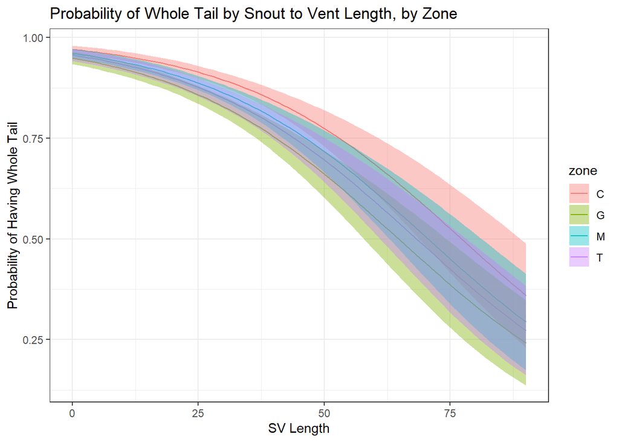

```r
## ------Repeat for zone------

# Simulate SV length
SV_length_vector_2 <- rep(seq(from = 0, to = 90), 4)

# Keep sex constant at "J"
sex_vector_2 <- rep("J", length(SV_length_vector_2))

# Simulate zone data repeating "F", "J", "M"
zone_vector_2 <- rep(c("C", "G", "M", "T"), each = length(seq(from = 0, to = 90)))

# Combine into data frame
data_pred_zone <- data.frame(SV_length_vector_2, zone_vector_2, sex_vector_2)

#rename columns
colnames(data_pred_zone) <- c("SV_length", "zone", "sex")

# Predict using model
prediction_zone <- predict(tail_model,
                      newdata = data_pred_zone,
                      type = "response",
                      se.fit = TRUE)

# Create final data frame with prediction results
data_fig_2 <- data.frame(data_pred_zone,
                       prediction_zone$fit,
                       prediction_zone$se.fit)

# Rename columns
colnames(data_pred_zone) <- c("SV_length", "zone", "sex")

colnames(data_fig_2) <- c("SV_length", "zone", "sex", "probability", "se")

# Graph probability of a lizard tail being whole as lizard length increases, with lines colored by zone
ggplot(data_fig_2, aes(x = SV_length, y = probability)) +
  geom_line(aes(color = zone)) +
  geom_ribbon(aes(ymin = probability - se,
                  ymax = probability + se,
                  fill = zone), alpha = 0.4) +
  labs(x = "SV Length",
       y = "Probability of Having Whole Tail",
       fill = "zone") +
  theme_bw() +
  ggtitle("Probability of Whole Tail by Snout to Vent Length, by Zone")
```

## Poisson Regression

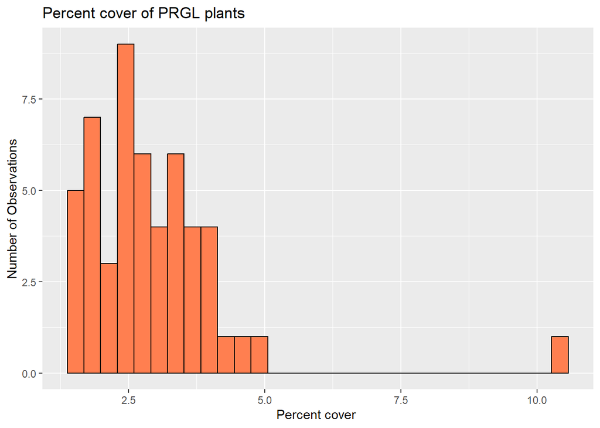

```r
#load data
lizard_plant <-read.csv('jrn_lizard_npp.csv')

# Research question: Do seasons and plant species cover significantly predict lizard counts?

#Analyze data (plant cover % by type, and seasons)

p4 <- ggplot(lizard_plant, aes(x = PRGL)) +
  geom_histogram(fill = "coral", color = "black") +
  labs(title = "Percent cover of PRGL plants", x = "Percent cover ", y = "Number of Observations")

p5 <- ggplot(lizard_plant, aes(x = BOER)) +
  geom_histogram(fill = "coral", color = "black") +
  labs(title = "Percent cover of BOER plants", x = "Percent cover ", y = "Number of Observations")

p6 <- ggplot(lizard_plant, aes(x = SCBR)) +
  geom_histogram(fill = "coral", color = "black") +
  labs(title = "Percent cover of SCBR plants", x = "Percent cover ", y = "Number of Observations")

p7 <- ggplot(lizard_plant, aes(x = LATR)) +
  geom_histogram(fill = "coral", color = "black") +
  labs(title = "Percent cover of LATR plants", x = "Percent cover ", y = "Number of Observations")

p8 <- ggplot(lizard_plant, aes(x = season)) +
  geom_bar(fill = "magenta3", color = "black") +
  labs(title = "Lizard count by season", x = "Season ", y = "Number of Observations")

p9 <- ggplot(lizard_plant, aes(x = BOER, y = lizard_count))+
  geom_point()

p10<- ggplot(lizard_plant, aes(x = PRGL, y = lizard_count))+
  geom_point()


p11<- ggplot(lizard_plant, aes(x = SCBR, y = lizard_count))+
  geom_point()

p12<- ggplot(lizard_plant, aes(x = LATR, y = lizard_count))+
  geom_point()

p13<- ggplot(lizard_plant, aes(x = season, y = lizard_count, color=season))+
  geom_point()

#plot
p4
```

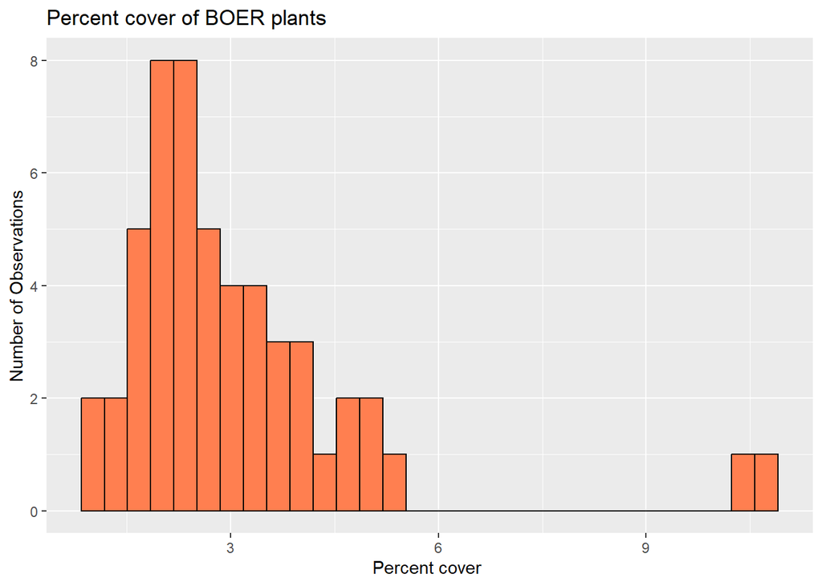

```r
p5
```

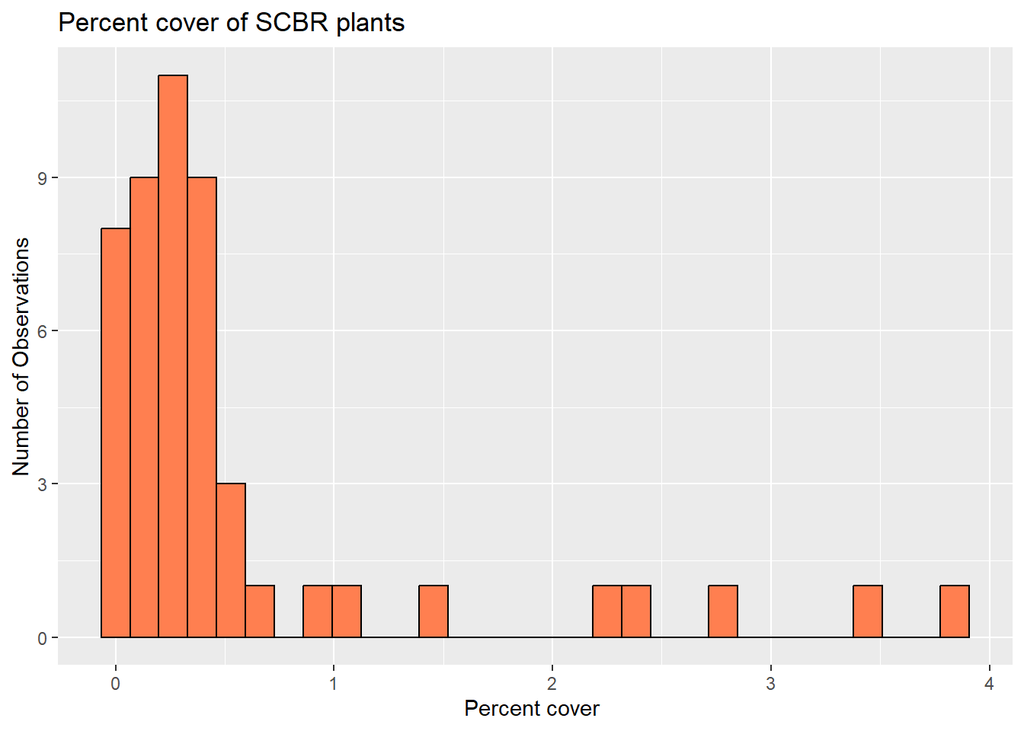

```r
p6
```

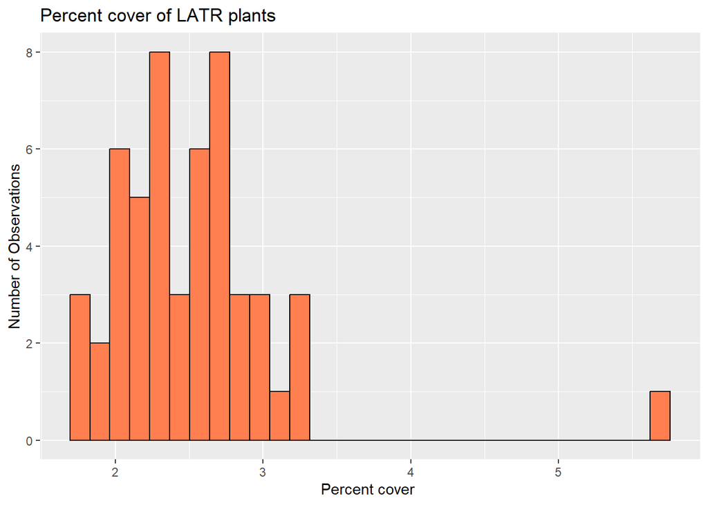

```r
p7
```

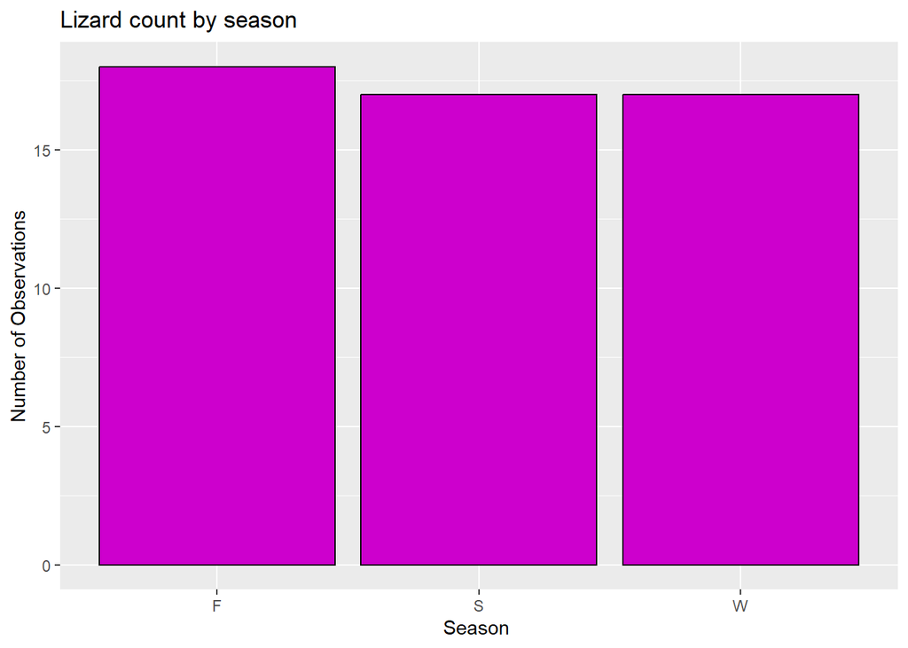

```r
p8
```

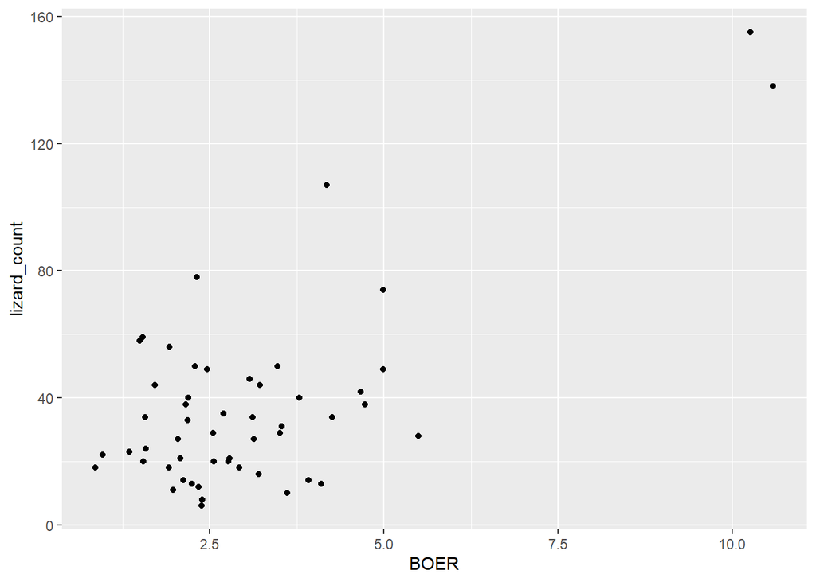

```r
p9
```

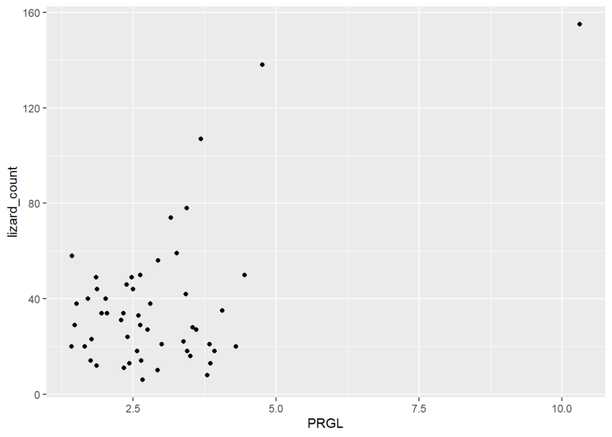

```r
p10
```